# Day 2 – Exercise Solutions

Seminar reference solutions

Use these solutions after the workshop to debrief or double-check the exercises (bonus included).

# Solution – Explore Data

Use this key after attempting `scripts/individual_notebooks/01_explore_data_exercises.Rmd`. The code chunks mirror the TODOs but include one possible solution for each task.

## 1. Load and preview the dataset

```r
input_path <- file.path('..', 'data', 'dataset2_subset_long.csv')
long_df <- read.csv(input_path, stringsAsFactors = FALSE, check.names = FALSE)
cat('Rows:', nrow(long_df), '\\nColumns:', ncol(long_df), '\\n')
```

```
## Rows: 3072 \nColumns: 7 \n
```

```r
head(long_df)
```

```
##                         Genome      snp_id Position    value mouse_id day
## 1 Akkermansia_muciniphila_YL44  239840-C-G   239840 0.000000     1683   0
## 2 Akkermansia_muciniphila_YL44  241793-A-G   241793 0.049587     1683   0
## 3 Akkermansia_muciniphila_YL44  355328-A-T   355328 0.138182     1683   0
## 4 Akkermansia_muciniphila_YL44  356291-C-A   356291 0.000000     1683   0
## 5 Akkermansia_muciniphila_YL44 2351445-C-T  2351445 0.000000     1683   0
## 6   Bacteroides_caecimuris_I48 1601848-T-C  1601848 0.041609     1683   0
##   treatment_group
## 1         Control
## 2         Control
## 3         Control
## 4         Control
## 5         Control
## 6         Control
```

## 2. Enumerate genomes and SNPs

```r
unique(long_df$Genome)
```

```
## [1] "Akkermansia_muciniphila_YL44" "Bacteroides_caecimuris_I48"
## [3] "Turicimonas_muris_YL45"
```

```r
table(long_df$Genome)
```

```
##
## Akkermansia_muciniphila_YL44   Bacteroides_caecimuris_I48
##                          320                         1216
##       Turicimonas_muris_YL45
##                         1536
```

```r
tapply(long_df$snp_id, long_df$Genome, function(x) length(unique(x)))
```

```
## Akkermansia_muciniphila_YL44   Bacteroides_caecimuris_I48
##                            5                           19
##       Turicimonas_muris_YL45
##                           24
```

## 3. Summaries by genome

```r
sample_values <- long_df$value[1:10]
summary(sample_values)
```

```
##    Min. 1st Qu.  Median    Mean 3rd Qu.    Max.
## 0.00000 0.00000 0.00000 0.03426 0.04759 0.13818
```

```r
aggregate(value ~ Genome, data = long_df, function(x) summary(x))
```

```
##                         Genome value.Min. value.1st Qu. value.Median value.Mean
## 1 Akkermansia_muciniphila_YL44  0.0000000     0.0000000    0.0523090  0.1741893
## 2   Bacteroides_caecimuris_I48  0.0000000     0.0000000    0.0338305  0.1485411
## 3       Turicimonas_muris_YL45  0.0000000     0.0000000    0.2649125  0.4312851
##   value.3rd Qu. value.Max.
## 1     0.2714463  0.8712450
## 2     0.2679232  0.9912180
## 3     0.9090910  1.0000000
```

## 4. Focus on Turicimonas

```r
turicimonas_df <- long_df[long_df$Genome == 'Turicimonas_muris_YL45', ]
cat('Rows for Turicimonas:', nrow(turicimonas_df), '\\n')
```

```
## Rows for Turicimonas: 1536 \n
```

```r
head(turicimonas_df)
```

```
##                    Genome      snp_id Position    value mouse_id day
## 25 Turicimonas_muris_YL45  362534-G-A   362534 1.000000     1683   0
## 26 Turicimonas_muris_YL45 1063346-G-A  1063346 0.741935     1683   0
## 27 Turicimonas_muris_YL45 1135479-G-A  1135479 0.000000     1683   0
## 28 Turicimonas_muris_YL45 1364256-G-A  1364256 0.406250     1683   0
## 29 Turicimonas_muris_YL45 1376518-G-A  1376518 0.000000     1683   0
## 30 Turicimonas_muris_YL45 1392383-G-A  1392383 0.461538     1683   0
##    treatment_group
## 25         Control
## 26         Control
## 27         Control
## 28         Control
## 29         Control
## 30         Control
```

```r
table(turicimonas_df$mouse_id, turicimonas_df$day)
```

```
##
##         0  4  9 14 18 23 30 37 44 49 53 58 63 67 72 79
##   1683 24 24 24 24 24 24 24 24 24 24 24 24 24 24 24 24
##   1688 24 24 24 24 24 24 24 24 24 24 24 24 24 24 24 24
##   1692 24 24 24 24 24 24 24 24 24 24 24 24 24 24 24 24
##   1699 24 24 24 24 24 24 24 24 24 24 24 24 24 24 24 24
```

## 5. Allele-frequency focus (Turicimonas vs all genomes)

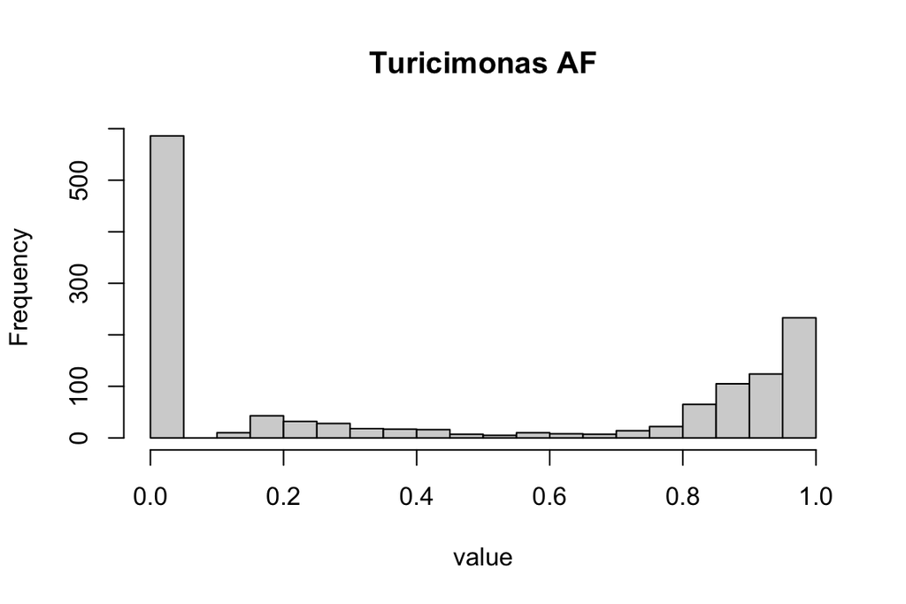

```r
turicimonas_values <- long_df$value[long_df$Genome == 'Turicimonas_muris_YL45']
hist(turicimonas_values, breaks = 20, main = 'Turicimonas AF', xlab = 'value')
```

```r
summary(turicimonas_values)
```

```
##    Min. 1st Qu.  Median    Mean 3rd Qu.    Max.    NA's
##  0.0000  0.0000  0.2649  0.4313  0.9091  1.0000     186
```

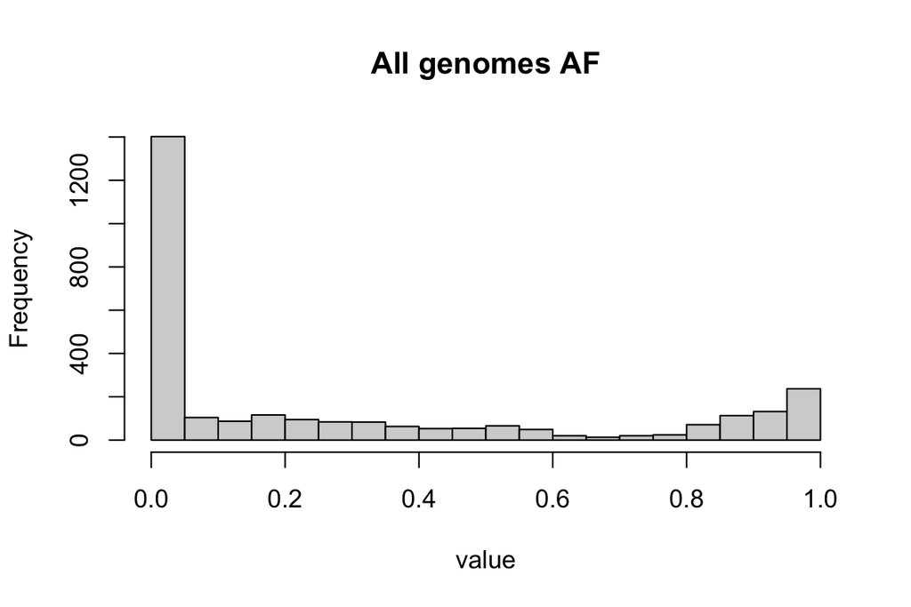

```r
hist(long_df$value, breaks = 30, main = 'All genomes AF', xlab = 'value')
```

```r
summary(long_df$value)
```

```
##    Min. 1st Qu.  Median    Mean 3rd Qu.    Max.    NA's
## 0.00000 0.00000 0.06438 0.28365 0.51995 1.00000     186
```

## 6. Missing values

```r
na_total <- sum(is.na(long_df$value))
na_total
```

```
## [1] 186
```

```r
na_by_mouse_day <- with(long_df, tapply(value, list(mouse_id, day), function(x) sum(is.na(x))))
na_by_mouse_day
```

```
##       0  4  9 14 18 23 30 37 44 49 53 58 63 67 72 79
## 1683  0  1  0  1  3  2  1  0  0  2  0  1  0  0  0  1
## 1688 15  1  0  1  0  0  0  0  0  0  0  0  0  0  0  1
## 1692  0 24 24  0 24 20  6  0  1  8 16  0  0  6  0  0
## 1699  0  0 24  0  1  0  0  0  1  0  0  0  1  0  0  0
```

## 7. Treatment groups

```r
unique(long_df$treatment_group)
```

```
## [1] "Control"       "Ciprofloxacin" "Tetracyclin"   "Vancomycin"
```

```r
table(long_df$treatment_group)
```

```
##
## Ciprofloxacin       Control   Tetracyclin    Vancomycin
##           768           768           768           768
```

```r
table(long_df$mouse_id, long_df$treatment_group)
```

```
##
##        Ciprofloxacin Control Tetracyclin Vancomycin
##   1683             0     768           0          0
##   1688           768       0           0          0
##   1692             0       0         768          0
##   1699             0       0           0        768
```

```r
long_df[long_df$day == 30, c('mouse_id','treatment_group')]
```

```
##      mouse_id treatment_group
## 193      1683         Control
## 194      1683         Control
## 195      1683         Control
## 196      1683         Control
## 197      1683         Control
## 198      1683         Control
## 199      1683         Control
## 200      1683         Control
## 201      1683         Control
## 202      1683         Control
## 203      1683         Control
## 204      1683         Control
## 205      1683         Control
## 206      1683         Control
```

[output cut: 178 more lines]

## 8. Stretch idea

```r
day30 <- long_df[long_df$day == 30, ]
medians_day30 <- tapply(day30$value, day30$Genome, median, na.rm = TRUE)
medians_day30
```

```
## Akkermansia_muciniphila_YL44   Bacteroides_caecimuris_I48
##                     0.124955                     0.030887
##       Turicimonas_muris_YL45
##                     0.250000
```

```r
medians_day30[which.max(medians_day30)]
```

```
## Turicimonas_muris_YL45
##                   0.25
```

Feel free to compare your answers with these outputs, then proceed to `scripts/individual_notebooks/02_simple_heatmap.Rmd`.

# Solution – Simple Heatmap

Below is one possible solution for the worksheet that builds the heatmap from `dataset2_subset.csv` / `dataset2_subset_long.csv` (three genomes). Feel free to compare this with your own approach.

## 1. Load packages and define paths

```r
library(ComplexHeatmap)
library(circlize)
subset_path <- file.path('..', 'data', 'dataset2_subset.csv')
long_path <- file.path('..', 'data', 'dataset2_subset_long.csv')
pdf_path <- file.path('..', 'pdf', 'dataset2_heatmap.pdf')
```

## 2. Load/inspect the data

```r
wide_df <- read.csv(subset_path, check.names = FALSE, stringsAsFactors = FALSE)
long_df <- read.csv(long_path, check.names = FALSE, stringsAsFactors = FALSE)

cat('Wide table dimensions:', nrow(wide_df), 'rows x', ncol(wide_df), 'columns\n')
```

```
## Wide table dimensions: 48 rows x 67 columns
```

```r
cat('Long table dimensions:', nrow(long_df), 'rows x', ncol(long_df), 'columns\n')
```

```
## Long table dimensions: 3072 rows x 7 columns
```

```r
head(wide_df[, c('Genome', 'snp_id', 'Position')])
```

```
##                         Genome      snp_id Position
## 1 Akkermansia_muciniphila_YL44  239840-C-G   239840
## 2 Akkermansia_muciniphila_YL44  241793-A-G   241793
## 3 Akkermansia_muciniphila_YL44  355328-A-T   355328
## 4 Akkermansia_muciniphila_YL44  356291-C-A   356291
## 5 Akkermansia_muciniphila_YL44 2351445-C-T  2351445
## 6   Bacteroides_caecimuris_I48 1601848-T-C  1601848
```

```r
head(long_df)
```

```
##                         Genome      snp_id Position    value mouse_id day
## 1 Akkermansia_muciniphila_YL44  239840-C-G   239840 0.000000     1683   0
## 2 Akkermansia_muciniphila_YL44  241793-A-G   241793 0.049587     1683   0
## 3 Akkermansia_muciniphila_YL44  355328-A-T   355328 0.138182     1683   0
## 4 Akkermansia_muciniphila_YL44  356291-C-A   356291 0.000000     1683   0
## 5 Akkermansia_muciniphila_YL44 2351445-C-T  2351445 0.000000     1683   0
## 6   Bacteroides_caecimuris_I48 1601848-T-C  1601848 0.041609     1683   0
##   treatment_group
## 1         Control
## 2         Control
## 3         Control
## 4         Control
## 5         Control
## 6         Control
```

## 3. Choose a treatment group subset

```r
target_group <- 'Control'
sample_meta <- unique(long_df[, c('mouse_id', 'day', 'treatment_group')])
sample_meta$sample_id <- paste(sample_meta$mouse_id, sample_meta$day, sep = '-')
keep_samples <- sample_meta$sample_id[sample_meta$treatment_group == target_group]
wide_df <- wide_df[, c('Genome', 'snp_id', 'Position', keep_samples)]
```

## 4. Quick summaries

```r
print(table(wide_df$Genome))
```

```
##
## Akkermansia_muciniphila_YL44   Bacteroides_caecimuris_I48
##                            5                           19
##       Turicimonas_muris_YL45
##                           24
```

```r
mouse_day_table <- with(long_df, table(mouse_id, day))
print(mouse_day_table)
```

```
##         day
## mouse_id  0  4  9 14 18 23 30 37 44 49 53 58 63 67 72 79
##     1683 48 48 48 48 48 48 48 48 48 48 48 48 48 48 48 48
##     1688 48 48 48 48 48 48 48 48 48 48 48 48 48 48 48 48
##     1692 48 48 48 48 48 48 48 48 48 48 48 48 48 48 48 48
##     1699 48 48 48 48 48 48 48 48 48 48 48 48 48 48 48 48
```

```r
value_summary <- tapply(long_df$value, long_df$Genome, function(x) {
  c(min = min(x, na.rm = TRUE),
    median = median(x, na.rm = TRUE),
    max = max(x, na.rm = TRUE))
})
value_summary <- do.call(rbind, value_summary)
print(value_summary)
```

```
##                              min    median      max
## Akkermansia_muciniphila_YL44   0 0.0523090 0.871245
## Bacteroides_caecimuris_I48     0 0.0338305 0.991218
## Turicimonas_muris_YL45         0 0.2649125 1.000000
```

## 5. Build the heatmap matrix

```r
sample_cols <- setdiff(names(wide_df), c('Genome', 'snp_id', 'Position'))
heatmap_matrix <- as.matrix(wide_df[, sample_cols])
mode(heatmap_matrix) <- 'numeric'
rownames(heatmap_matrix) <- paste(wide_df$Genome, wide_df$snp_id, sep = ' | ')

sample_meta <- data.frame(sample_id = sample_cols, stringsAsFactors = FALSE)
split_ids <- strsplit(sample_meta$sample_id, '-', fixed = TRUE)
sample_meta$mouse_id <- vapply(split_ids, function(x) x[[1]], character(1))
sample_meta$day <- as.integer(vapply(split_ids, function(x) if (length(x) >= 2) x[[2]] else NA_character_, character(1)))

order_idx <- order(sample_meta$mouse_id, sample_meta$day, sample_meta$sample_id)
sample_meta <- sample_meta[order_idx, ]
heatmap_matrix <- heatmap_matrix[, sample_meta$sample_id, drop = FALSE]
```

## 6. Colors and annotations

```r
min_val <- min(heatmap_matrix, na.rm = TRUE)
max_val <- max(heatmap_matrix, na.rm = TRUE)
if (!is.finite(min_val)) min_val <- 0
if (!is.finite(max_val)) max_val <- 1
if (abs(max_val - min_val) < .Machine$double.eps) {
  max_val <- min_val + 1
}
mid_val <- (min_val + max_val) / 2
color_fun <- circlize::colorRamp2(c(min_val, mid_val, max_val),
                                  c('#0c2c84', '#f7fbff', '#b30000'))

mouse_levels <- unique(sample_meta$mouse_id)
mouse_colors <- setNames(grDevices::rainbow(length(mouse_levels)), mouse_levels)

min_day <- min(sample_meta$day, na.rm = TRUE)
max_day <- max(sample_meta$day, na.rm = TRUE)
if (min_day == max_day) {
  day_colors <- circlize::colorRamp2(c(min_day, min_day + 1), c('#fee8c8', '#e34a33'))
} else {
  day_colors <- circlize::colorRamp2(seq(min_day, max_day, length.out = 3),
                                     c('#fee8c8', '#fdbb84', '#e34a33'))
}

col_annotation <- HeatmapAnnotation(
  mouse = factor(sample_meta$mouse_id, levels = mouse_levels),
  day = sample_meta$day,
  col = list(mouse = mouse_colors, day = day_colors),
  annotation_name_side = 'left'
)
```

## 7. Draw and export the heatmap

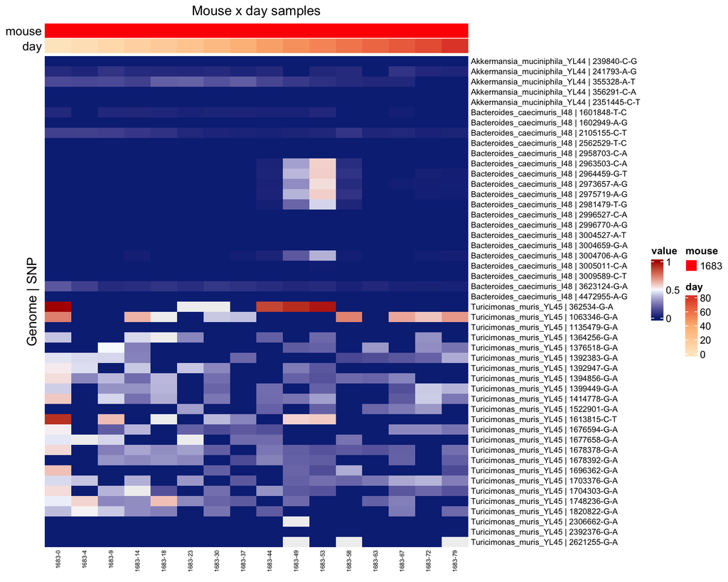

```r
row_name_size <- max(5, min(8, 40 / log10(max(10, nrow(heatmap_matrix)))))
col_name_size <- max(6, min(10, 80 / ncol(heatmap_matrix)))

ht <- Heatmap(
  heatmap_matrix,
  name = 'value',
  col = color_fun,
  na_col = '#f0f0f0',
  top_annotation = col_annotation,
  column_split = factor(sample_meta$mouse_id, levels = mouse_levels),
  cluster_rows = FALSE,
  cluster_columns = FALSE,
  column_title = 'Mouse x day samples',
  row_title = 'Genome | SNP',
  show_row_names = TRUE,
  show_column_names = TRUE,
  row_names_gp = grid::gpar(fontsize = row_name_size),
  column_names_gp = grid::gpar(fontsize = col_name_size)
)

draw(ht, heatmap_legend_side = 'right', annotation_legend_side = 'right')
```

```r
pdf_height <- max(6, min(18, 0.2 * nrow(heatmap_matrix) + 4))
pdf_width <- max(8, min(16, 0.2 * ncol(heatmap_matrix) + 6))

dir.create(dirname(pdf_path), recursive = TRUE, showWarnings = FALSE)
pdf(pdf_path, width = pdf_width, height = pdf_height)
draw(ht, heatmap_legend_side = 'right', annotation_legend_side = 'right')
dev.off()
```

```r
cat('Saved heatmap to', pdf_path, '\n')
```

```
## Saved heatmap to ../pdf/dataset2_heatmap.pdf
```

For extra practice, try adding `row_split` by Genome or experiment with a different color palette.

# Solution – Full Heatmap

This solution notebook offers one way to complete the full heatmap exercise. Feel free to tweak palettes, ordering, or filtering thresholds to suit your teaching needs.

## 1. Packages, paths, helpers

```r
suppressPackageStartupMessages({
  library(ComplexHeatmap)
  library(circlize)
  library(viridisLite)
})
subset_path <- file.path('..','data','dataset3_subset.csv')
long_path   <- file.path('..','data','dataset3_subset_long.csv')
pdf_path    <- file.path('..','pdf','04_full_heatmap_exercise.pdf')
na_color <- '#dcdcdc'
```

## 2. Load data and NA report

```r
wide_df <- read.csv(subset_path, check.names = FALSE, stringsAsFactors = FALSE)
long_df <- read.csv(long_path, check.names = FALSE, stringsAsFactors = FALSE)
cat('Wide rows x cols:', nrow(wide_df), ncol(wide_df), '\n')
```

```
## Wide rows x cols: 71 67
```

```r
cat('Long rows x cols:', nrow(long_df), ncol(long_df), '\n')
```

```
## Long rows x cols: 4544 7
```

```r
na_total <- sum(is.na(long_df$value))
cat('NA count (value):', na_total, '\n')
```

```
## NA count (value): 443
```

```r
if (na_total > 0) {
  na_table <- with(long_df, tapply(value, list(mouse_id, day), function(x) sum(is.na(x))))
  print(na_table)
}
```

```
##       0  4  9 14 18 23 30 37 44 49 53 58 63 67 72 79
## 1683  0  1  2  3  4  4  2  0  1  2  1  1  1  0  1  1
## 1688 15  1  1  2  3  0  1  1  0  0  0  1  0  0  1  1
## 1692  0 47 24  0 46 20  6  0  1  9 38  0  0 28  0  0
## 1699  0 23 37  0 24 13  0  0  1  1 23 13  1 23 13  1
```

## 3. Matrix + metadata

```r
sample_cols <- setdiff(names(wide_df), c('Genome','snp_id','Position'))
mat <- as.matrix(wide_df[, sample_cols])
mode(mat) <- 'numeric'
rownames(mat) <- paste(wide_df$Genome, wide_df$snp_id, sep = ' | ')

sample_meta <- unique(long_df[, c('mouse_id','day','treatment_group')])
sample_meta$sample_id <- paste(sample_meta$mouse_id, sample_meta$day, sep='-')
sample_meta <- sample_meta[match(colnames(mat), sample_meta$sample_id), ]
stopifnot(identical(colnames(mat), sample_meta$sample_id))
```

## 4. Baseline heatmap + palettes

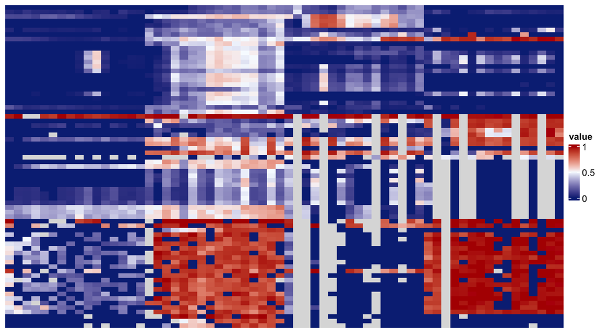

```r
mins <- min(mat, na.rm = TRUE)
maxs <- max(mat, na.rm = TRUE)
mids <- (mins + maxs) / 2
palette_blue_red <- circlize::colorRamp2(c(mins, mids, maxs), c('#0c2c84','#f7fbff','#b30000'))
palette_viridis <- circlize::colorRamp2(c(mins, mids, maxs), viridisLite::viridis(3))

ht_blue <- Heatmap(mat, name = 'value', col = palette_blue_red, na_col = na_color,
                   cluster_rows = FALSE, cluster_columns = FALSE,
                   show_row_names = FALSE, show_column_names = FALSE)
ht_viridis <- Heatmap(mat, name = 'value', col = palette_viridis, na_col = na_color,
                      cluster_rows = FALSE, cluster_columns = FALSE,
                      show_row_names = FALSE, show_column_names = FALSE)

ht_blue
```

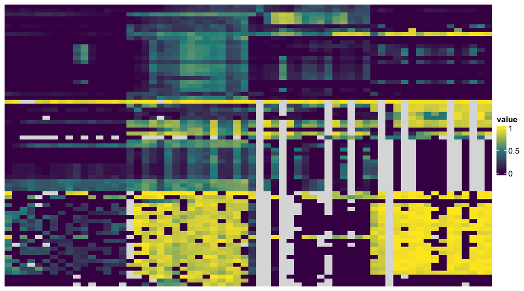

```r
ht_viridis
```

## 5. Annotations + ordering

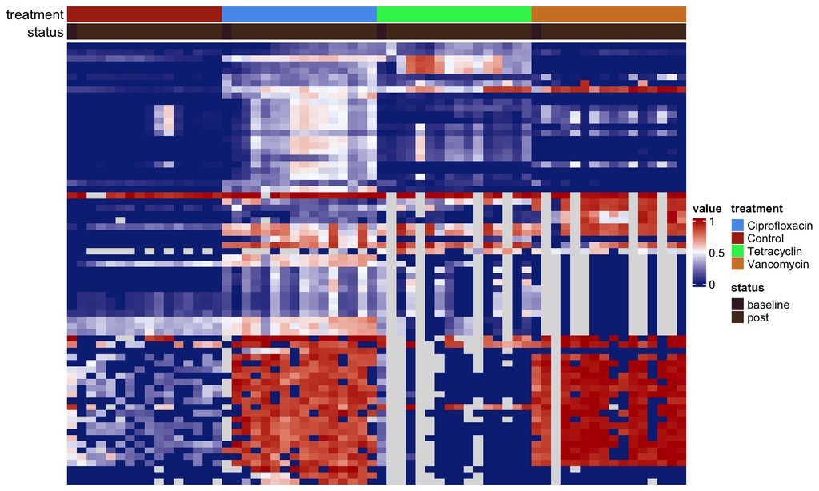

```r
sample_meta$post_ab <- ifelse(sample_meta$day == 0, 'baseline', 'post')
col_ann <- HeatmapAnnotation(
  treatment = sample_meta$treatment_group,
  status = sample_meta$post_ab,
  annotation_name_side = 'left'
)
order_idx <- order(sample_meta$mouse_id, sample_meta$day)
mat_ordered <- mat[, order_idx]
col_ann_ordered <- col_ann[order_idx]

Heatmap(
  mat_ordered,
  name = 'value',
  col = palette_blue_red,
  top_annotation = col_ann_ordered,
  cluster_rows = FALSE,
  cluster_columns = FALSE,
  show_row_names = FALSE,
  show_column_names = FALSE,
  na_col = na_color
)
```

## 6. Annotation enhancements

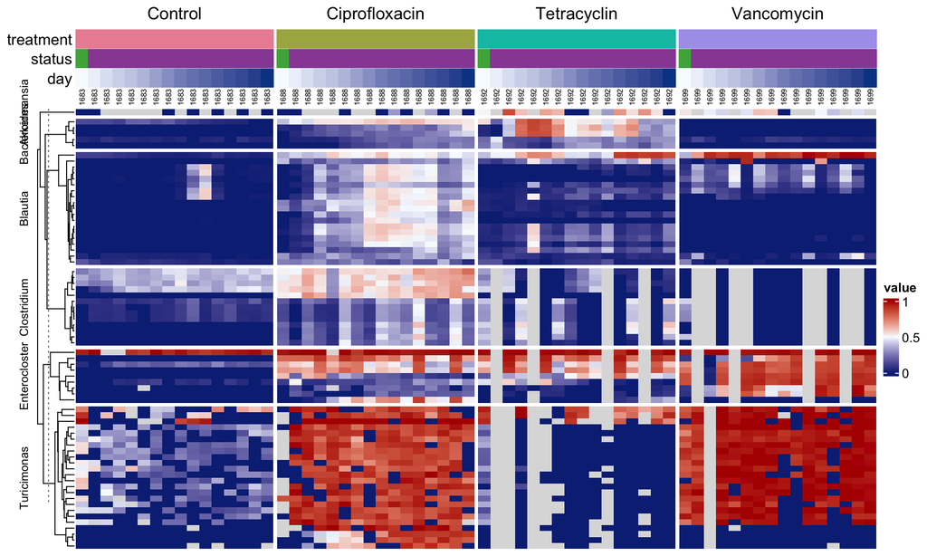

```r
treatment_levels <- unique(sample_meta$treatment_group)
treatment_cols <- grDevices::hcl.colors(length(treatment_levels), palette = "Set2")
names(treatment_cols) <- treatment_levels
status_cols <- c(baseline = '#4daf4a', post = '#984ea3')
day_col_fun <- circlize::colorRamp2(range(sample_meta$day), c('#f7fbff','#084594'))
col_ann_rich <- HeatmapAnnotation(
  treatment = anno_simple(sample_meta$treatment_group, col = treatment_cols),
  status = anno_simple(sample_meta$post_ab, col = status_cols),
  day = anno_simple(sample_meta$day, col = day_col_fun),
  mouse = anno_text(sample_meta$mouse_id, rot = 90, gp = grid::gpar(fontsize = 6)),
  annotation_name_side = 'left'
)
col_ann_rich_ordered <- col_ann_rich[order_idx]
column_split <- factor(sample_meta$treatment_group[order_idx], levels = treatment_levels)
row_split <- factor(wide_df$Genome, levels = unique(wide_df$Genome))
row_titles <- sub('_.*', '', levels(row_split))

Heatmap(
  mat_ordered,
  name = 'value',
  col = palette_blue_red,
  top_annotation = col_ann_rich_ordered,
  cluster_rows = TRUE,
  cluster_columns = FALSE,
  column_split = column_split,
  show_row_names = FALSE,
  show_column_names = FALSE,
  na_col = na_color,
  row_split = row_split,
  row_title = row_titles,
  row_title_gp = grid::gpar(fontsize = 9)
)
```